# Analiza zbioru danych cukrzyca

Projekt opiera się o dane dotyczące zachorowań na cukrzycę wśród kobiet. Jest to oryginalny zbiór danych pochodzący z National Institute of Diabetes and Digestive and Kidney Diseases. Składa się z następujących zmiennych:

- **Pregnancies** - liczba ciąż,
- **Glucose** - stężenie glukozy w osoczu przez 2 godziny w teście doustnej tolerancji glukozy,
- **BloodPressure** - rozkurczowe ciśnienie krwi ($mm Hg $),
- **SkinThickness** - grubość fałdu skóry tricepsa ($mm$),
- **Insulin** - 2-godzinna insulina w surowicy ($ \frac{mu U}{ml} $),
- **BMI** - wskaźnik masy ciała ($ \frac{waga}{wzrost^2} $ $ \frac{kg}{m} $) ,
- **DiabetesPedigreeFunction** - funkcja rodowodu cukrzycy,
- **Age** - wiek ($lata$),
- **Outcome** - czy kobieta zachorowała ($1$), czy nie ($0$).

### Plan projektu:

1. Przedstawienie i opis danych.
2. Detekcja i ewentualne rozwiązanie problemu brakujących obserwacji.
3. Wizualizacja danych.
4. Klasyfikacja.
5. Klasteryzacja.
6. Skalowanie wielowymiarowe.
7. Porównanie wyników.
8. Podsumowanie.

Poniżej znajdują się biblioteki użyte w projekcie:

```python
#libraries used in the project
import pandas as pd
import numpy as np
import random
from sklearn import linear_model
import matplotlib.pyplot as plt
import seaborn as sns


from sklearn.model_selection import KFold
from sklearn.model_selection import cross_val_score
from sklearn.model_selection import GridSearchCV
from sklearn.linear_model import LogisticRegression
from sklearn.naive_bayes import GaussianNB
from sklearn.neighbors import KNeighborsClassifier
from sklearn.tree import DecisionTreeClassifier
from sklearn.svm import SVC
from sklearn.metrics import confusion_matrix
from sklearn.metrics import accuracy_score
from sklearn.metrics import classification_report
from sklearn.model_selection import train_test_split
from sklearn.preprocessing import StandardScaler
from sklearn.metrics.pairwise import pairwise_distances
from sklearn.manifold import MDS
from sklearn.cluster import AgglomerativeClustering
from sklearn.cluster import KMeans
import scipy.cluster.hierarchy as sch
import random
import warnings
warnings.filterwarnings('ignore')
from scipy import stats

#centered
from IPython.core.display import HTML
HTML("""
<style>
.output_png {
display: table-cell;
text-align: center;
vertical-align: middle;
}
</style>
""")
```

# 1. Przedstawienie i opis danych

Poniżej wczytano dane i przedstawiono informacje o typie zmiennych.

```python
#uploading the data and getting information about dataset
cukrzyca = pd.read_csv("D:/Informatyka i Ekonometria/Informatyka i Ekonometria/Semestr 2 magisterka/Python/projekt/diabetes.csv")
cukrzyca.info()
```

```
<class 'pandas.core.frame.DataFrame'>
RangeIndex: 768 entries, 0 to 767
Data columns (total 9 columns):
Pregnancies                 768 non-null int64
Glucose                     768 non-null int64
BloodPressure               768 non-null int64
SkinThickness               768 non-null int64
Insulin                     768 non-null int64
BMI                         768 non-null float64
DiabetesPedigreeFunction    768 non-null float64
Age                         768 non-null int64
Outcome                     768 non-null int64
dtypes: float64(2), int64(7)
memory usage: 54.1 KB
```

W zbiorze jest 7 zmiennych numerycznych całkowitych i 2 zmiennoprzecinkowe, a są nimi BMI i funkcja rodowodu cukrzycy. Zmienna Outcome jest zmienną numeryczą o wartościach 1 i 0.

### Statystyki opisowe zmiennych:

```python
#descriptive statistics
cukrzyca.describe()
```

|  | Pregnancies | Glucose | BloodPressure | SkinThickness | Insulin | BMI | DiabetesPedigreeFunction | Age | Outcome |
| --- | --- | --- | --- | --- | --- | --- | --- | --- | --- |
| count | 768.000000 | 768.000000 | 768.000000 | 768.000000 | 768.000000 | 768.000000 | 768.000000 | 768.000000 | 768.000000 |
| mean | 3.845052 | 120.894531 | 69.105469 | 20.536458 | 79.799479 | 31.992578 | 0.471876 | 33.240885 | 0.348958 |
| std | 3.369578 | 31.972618 | 19.355807 | 15.952218 | 115.244002 | 7.884160 | 0.331329 | 11.760232 | 0.476951 |
| min | 0.000000 | 0.000000 | 0.000000 | 0.000000 | 0.000000 | 0.000000 | 0.078000 | 21.000000 | 0.000000 |
| 25% | 1.000000 | 99.000000 | 62.000000 | 0.000000 | 0.000000 | 27.300000 | 0.243750 | 24.000000 | 0.000000 |
| 50% | 3.000000 | 117.000000 | 72.000000 | 23.000000 | 30.500000 | 32.000000 | 0.372500 | 29.000000 | 0.000000 |
| 75% | 6.000000 | 140.250000 | 80.000000 | 32.000000 | 127.250000 | 36.600000 | 0.626250 | 41.000000 | 1.000000 |
| max | 17.000000 | 199.000000 | 122.000000 | 99.000000 | 846.000000 | 67.100000 | 2.420000 | 81.000000 | 1.000000 |

Sprawdzono więc, ile zer zawierają zmienne, które ich mieć nie powinny:

```python
#checking which columns have zeroes
for i in range(1,8):
    print(cukrzyca.columns[i],sum(cukrzyca.iloc[:,i]==0))
```

```
Glucose 5
BloodPressure 35
SkinThickness 227
Insulin 374
BMI 11
DiabetesPedigreeFunction 0
Age 0
```

Jest sporo 0, w szczególności w zmiennych Insulin oraz SkinThickness. Pojawiają się także w zmiennej Glucose - 5, BloodPressure - 35 oraz BMI - 11. W pozostałych zmiennych nie występują 0.

W zmiennych, w których występują niepożądane 0, zostaną one zamienione na wartości brakujące, czyli NaN. Następnie następuje sprawdzenie sumy wartości brakujących dla każdej zmiennej.

```python
#replacement of zeroes by NaN
cukrzyca[["Glucose","BloodPressure","SkinThickness","Insulin","BMI"]]=cukrzyca[["Glucose","BloodPressure","SkinThickness","Insulin","BMI"]].replace(0,np.NaN)
print(cukrzyca.isna().sum())
```

```
Pregnancies                   0
Glucose                       5
BloodPressure                35
SkinThickness               227
Insulin                     374
BMI                          11
DiabetesPedigreeFunction      0
Age                           0
Outcome                       0
dtype: int64
```

Wartości brakujące posiadają tylko te obserwacje, które wcześniej miały zera.

# 2. Brakujące obserwacje

Przed podjęciem próby poradzenia sobie z brakującymi obserwacjami, zostanie sprawdzony ich typ. Jesli nie będzie żadnego widocznego wzorca, będzie można uznać, że są to braki całkowicie losowe i w takim wypadku usunięcie nie spowodowałoby znacznej utraty informacji, jeśli jednak będzie widoczny wzorzec, nie można byłoby ich usunąć.

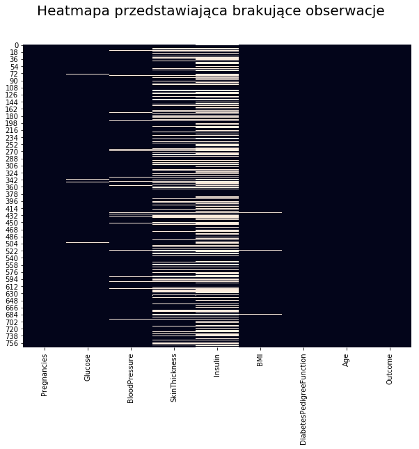

```python
#heatmap showing missing values
plt.subplots(nrows=1, ncols=1,figsize=(10,8))
plt.suptitle("Heatmapa przedstawiająca brakujące obserwacje", fontsize=20)
sns.heatmap(cukrzyca.isnull(), cbar=False)
```

Widać, że najwięcej jest obserwacji, które mają braki zarówno w zmiennej SkinThickness jak i Insulin. Chcąc więc usunąć brakujące obserwacje, doszłoby do utraty informacji o sporej grupie. W takim wypadku należy dokonać imputacji brakujących obserwacji. Imputacja zostanie dokonana na podstawie regresji. Jednak nie można jej użyć w sytuacji, gdy brakujące wartości są w kilku kolumnach, gdyż nie można robić prognozy wartości brakujących na podstawie kolumn, które także mają braki. Problem ten rozwiązuje metoda losowej imputacji (brakującym wartościom są przypisywane losowe wartości zmiennej), a następnie iteracyjnie następuje imputacja na podstawie regresji dla każdej ze zmiennych. Główną wadą tej metody jest to, że zmniejszamy naturalną zmienność przypisywanej zmiennej. Aby dodać niepewność do wartości zmiennych przypisywanych, można dodać trochę normalnie rozłożonego szumu ze średnią zero i wariancją równą standardowemu błędowi oszacowań regresji. Ta metoda jest nazywana **stochastyczną imputacją regresyjną**.

```python
#stochastic regression imputation
missing_cols = ["Glucose", "BloodPressure", "SkinThickness", "Insulin", "BMI"]
random.seed(1)
def random_imputation(df, feature):
    number_missing = df[feature].isnull().sum()
    observed_values = df.loc[df[feature].notnull(), feature]
    df.loc[df[feature].isnull(), feature + '_imp'] = np.random.choice(observed_values, number_missing, replace = True)
    return df

for feature in missing_cols:
    cukrzyca[feature + '_imp'] = cukrzyca[feature]
    cukrzyca = random_imputation(cukrzyca, feature)

imputed_data = pd.DataFrame(columns = ["Ran" + name for name in missing_cols])

for feature in missing_cols:

    imputed_data["Ran" + feature] = cukrzyca[feature + '_imp']
    parameters = list(set(cukrzyca.columns) - set(missing_cols) - {feature + '_imp'})

    model = linear_model.LinearRegression()
    model.fit(X = cukrzyca[parameters], y = cukrzyca[feature + '_imp'])

    predict = model.predict(cukrzyca[parameters])
    std_error = (predict[cukrzyca[feature].notnull()] - cukrzyca.loc[cukrzyca[feature].notnull(), feature + '_imp']).std()

    random_predict = np.random.normal(size = cukrzyca[feature].shape[0],
                                      loc = predict,
                                      scale = std_error)
    imputed_data.loc[(cukrzyca[feature].isnull()) & (random_predict > 0), "Ran" + feature] = random_predict[(cukrzyca[feature].isnull()) &
                                                                            (random_predict > 0)]
```

```python
#choosing columns and changing names
cukrzyca = pd.concat([cukrzyca.iloc[:,0],imputed_data,cukrzyca.iloc[:,6:9]],axis=1)
cukrzyca.columns = ["Pregnancies","Glucose","BloodPressure","SkinThickness","Insulin","BMI","DiabetesPedigreeFunction", "Age", "Outcome"]
```

Po uzupełnieniu brakujących obserwacji, ponownie zostaje sprawdzona ich suma w poszczególnych zmiennych.

```python
#sum of zeroes in columns
cukrzyca.isnull().sum()
```

```
Pregnancies                 0
Glucose                     0
BloodPressure               0
SkinThickness               0
Insulin                     0
BMI                         0
DiabetesPedigreeFunction    0
Age                         0
Outcome                     0
dtype: int64
```

Wszystkie braki zostały zastępione przewidywaniami regresji. W zbiorze nie ma więcej brakujących obserwacji.

Należy sprawdzić jak prezentują się rozkłady poszczególnych zmiennych przed i po imputacji. Poniżej znajdują się histogramy i wykresy pudełkowe zmiennych poddanych imputacji.

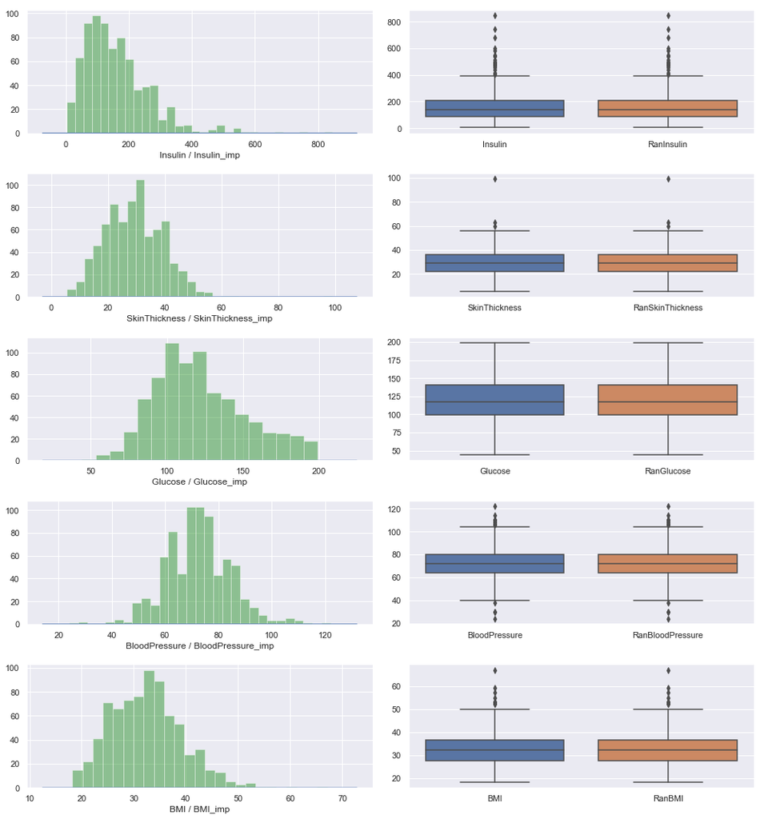

```python
#histograms and boxplots before and after imputation
sns.set()
fig, axes = plt.subplots(nrows = 5, ncols = 2)
fig.set_size_inches(14,15)

for index, variable in enumerate(["Insulin", "SkinThickness", "Glucose","BloodPressure","BMI"]):
    sns.distplot(cukrzyca[variable].dropna(), kde = True, ax = axes[index, 0])
    sns.distplot(imputed_data["Ran" + variable], kde = False, ax = axes[index, 0], color = 'green')
    axes[index, 0].set(xlabel = variable + " / " + variable + '_imp')

    sns.boxplot(data = pd.concat([cukrzyca[variable], imputed_data["Ran" + variable]], axis = 1),
                ax = axes[index, 1])

    plt.tight_layout()
```

Widać, że w przypadku każdej zmiennej rozkłady te są niemal identyczne. Są niewielkie różnice, ale ciężko je nawet dostrzec gołym okiem. Zmienne po imputacji mają takie same rozkłady jak te same zmienne przed imputacją.

# 3. Wizualizacja danych

Aby lepiej zrozumiec dane, najlepiej przedstawić je na wykresie. Poniżej zostały przedstawione zmienne objaśniające za pomocą boxplotów i histogramów, a także wykres częstości zmiennej objaśnianej.

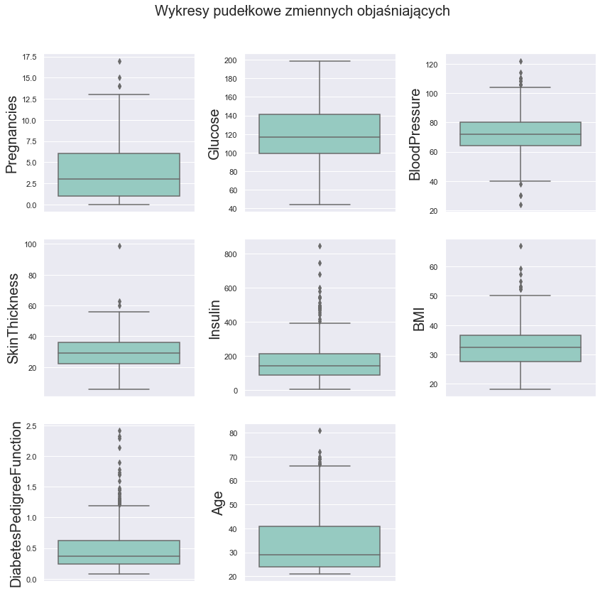

```python
#boxplots of explanatory variables
feature_names = cukrzyca.columns[0:8]
fig, axes = plt.subplots(nrows=3, ncols=3,figsize=(12,12))
fig.suptitle('Wykresy pudełkowe zmiennych objaśniających', fontsize=20)
for index, variable in enumerate(feature_names):
    sns.boxplot(variable,data=cukrzyca, ax=axes.flatten()[index], orient='v', palette="Set3")
    axes.flatten()[index].set_ylabel(variable,fontsize=20)
fig.delaxes(axes[2,2])
plt.tight_layout()
fig.subplots_adjust(top=0.9)
plt.show()
```

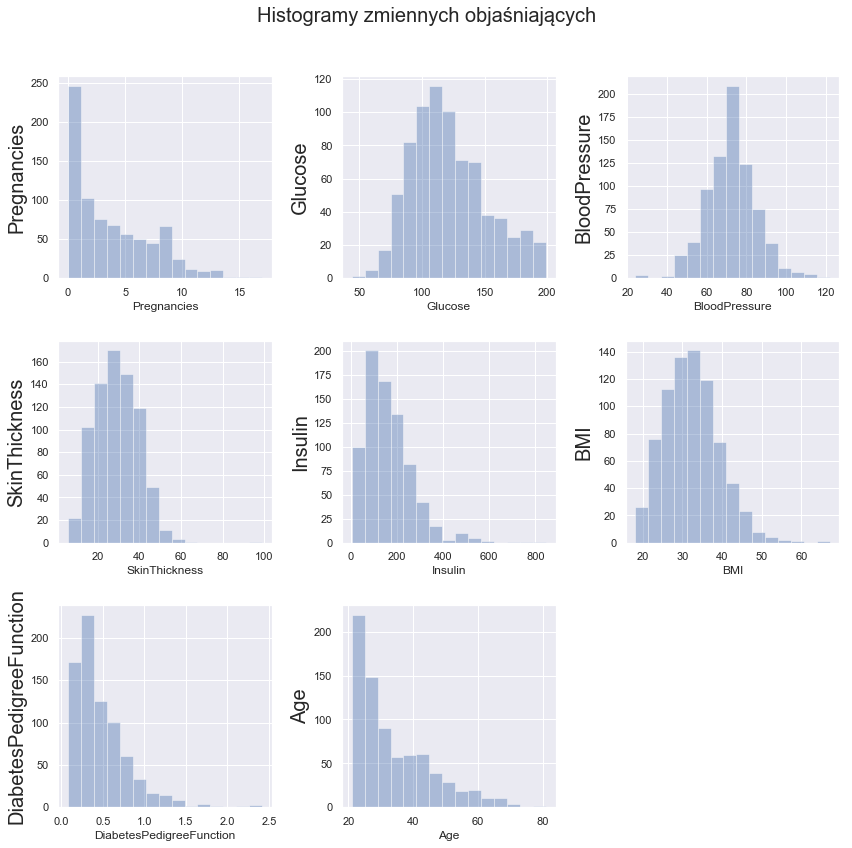

```python
#histograms of explanatory variables
fig, axes = plt.subplots(nrows=3, ncols=3,figsize=(12,12))
fig.suptitle('Histogramy zmiennych objaśniających', fontsize=20)
for index, variable in enumerate(feature_names):
    sns.distplot(cukrzyca[variable], ax=axes.flatten()[index],bins=15, kde=False)
    axes.flatten()[index].set_ylabel(variable,fontsize=20)
fig.delaxes(axes[2,2])
plt.tight_layout()
fig.subplots_adjust(top=0.9)
plt.show()
```

Na histogramach lepiej widać jakie dokładnie liczności miały poszczególne przedziały przedstawionych zmiennych.

Poniżej znajduje się wykres częstości kobiet chorujących na cukrzycę i tych zdrowych.

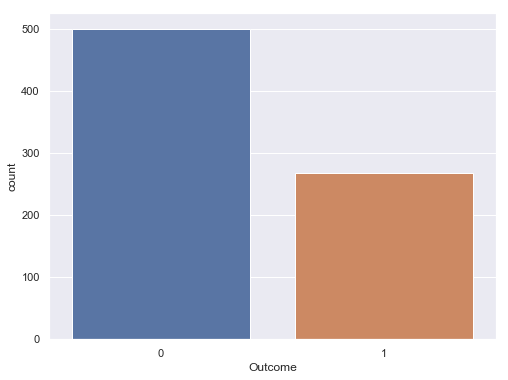

```python
#frequency chart
plt.figure(figsize=(8,6))
sns.countplot(cukrzyca['Outcome'])
plt.show()
```

Na 768 przebadanych kobiet, 500 było zdrowych, a 268 chorych na cukrzycę.

# 4. Klasyfikacja

Klasyfikacja jest przykładem uczenia "z nadzorem". Posiadając zbiór danych, zostaje on podzielony na zbiór treningowy - na nim algorytmy uczą się rozpoznawać klasę, oraz testowy - zbiór bez przypisania klasy, na nim jest testowana skuteczność algorytmu.

W tej części zostanie podjęta próba zaklasyfikowania badanych kobiet do grupy chorych (1) lub zdrowych (0). Modele będą uczyły się na zbiorze 70% obserwacji, dla których będzie znany wynik - zbiór treningowy. Następnie zostanie on przetestowany na zbiorze testowym - pozostałe 30% obserwacji. Zostaną użyte następujące klasyfikatory:

- Regresja logistyczna,
- KNN (K najbliższych sąsiadów),
- Drzewa decyzyjne,
- SVM (Support Vector Machine).

Macierz X to reprezentacja zmiennych objaśniających, zaś y to zmienna objaśniana. Ze względu na różnice w skali danych, zostaną one poddane standaryzacji.

Ocena klasyfikatora będzie opierała się o trafność prognozy - ile było poprawnie zaklasyfikowanych obserwacji. Wyniki zostaną przedstawione w formie macierzy dopasowań, która zawiera następujące miary:

- **prawdziwie pozytywna** - prawidłowe zaklasyfikowanie do klasy 1,
- **prawdziwie negatywna** - prawidłowe zaklasyfikowanie do klasy 0,
- **fałszywie pozytywna** - przypisanie do klasy 1, gdy w rzeczywistości należy do klasy 0, błąd pierwszego rodzaju
- **fałszywie negatywna** - przypisanie do klasy 0, gdy w rzeczywistości należy do klasy 1, błąd drugiego rodzaju

```python
#dividing dataset into training set and test set
X = cukrzyca.iloc[:, 0:8].values
y = cukrzyca.iloc[:, -1].values

X_train, X_test, y_train, y_test = train_test_split(X, y, test_size = 0.3, random_state = 0)

#standardization features by removing the mean and scaling to unit variance
sc=StandardScaler()
X_train = sc.fit_transform(X_train)
X_test = sc.transform(X_test)

train = pd.DataFrame(X_train, y_train)

#creating a classification chart
def wykres_klasyfikacja(y_pred_train):
    fig, ax = plt.subplots(ncols = 1, nrows=1, figsize=(7,7))

    chora = train.loc[y_pred_train == 1]
    zdrowa = train.loc[y_pred_train == 0]

    plt.scatter(chora.iloc[:, 0], chora.iloc[:, 1], s=10, label='Chora')
    plt.scatter(zdrowa.iloc[:, 0], zdrowa.iloc[:, 1], s=10, label='Zdrowa')
    plt.legend()
```

### Regresja logistyczna

Poniżej znajdują się wyniki klasyfikacji za pomocą Regresji logistycznej.

Regresja logistyczna służy do badania wpływu niezależnych zmiennych objaśniających {𝑥1,…,𝑥𝑛} na zmienną objaśnianą jakościową. Zmienna objaśniana najczęściej przyjmuje dwie wartości:

- 1 – rozważana sytuacja będzie miała miejsce;
- 0 – rozważana sytuacja nie będzie miała miejsca.

Wynik regresji logistycznej wyraża prawdopodobieństwo zajścia pewnego zdarzenia oraz przyjmuje wartość z przedziału 0-1. Aby zaklasyfikować obserwację do konkretnego scenariusza, ustala się tzw. próg odcięcia (ang.: cut off ). Na przykład $𝑃(𝑌=1|𝑋)>0.5$ oznacza, że jeżeli prawdopodobieństwo, że zmienna $𝑌$ przyjmie wartość 1 jest większe niż 50%, pod warunkiem zajścia zdarzenia 𝑋, zmiennej 𝑌 zostanie przypisana wartość 1, w przeciwnym razie 0. Model został stworzony w oparciu o najlepsze wartości parametrów: solver - algorytm użyty do problemu optymizacji oraz C - oferuje najmniejszą różnicę między dokładnością treningową i testową. Parametry estymatora są optymalizowane za pomocą sprawdzianu krzyżowego w siatce parametrów.

```python
#looking for the best params for the model and prediction based on this params
solvers = ['newton-cg', 'lbfgs', 'liblinear']
c_values = [10, 1.0, 0.1, 0.01]
hyperparameters = dict(solver = solvers,C = c_values)
logreg = LogisticRegression(random_state = 0)
clf = GridSearchCV(logreg,hyperparameters, cv=10)
logreg_best = clf.fit(X_train,y_train)

best_solver = logreg_best.best_estimator_.get_params()['solver']
best_c_lr = logreg_best.best_estimator_.get_params()['C']

y_pred_train_lr = logreg_best.predict(X_train)
y_pred_test_lr = logreg_best.predict(X_test)

LR_cm_train = confusion_matrix(y_train, y_pred_train_lr)
LR_cm_test = confusion_matrix(y_test, y_pred_test_lr)
```

**Trafność prognozy na zbiorze treningowym i testowym:**

```python
print("Trafność na zbiorze treningowym: ",round(accuracy_score(y_train,y_pred_train_lr),3))
print("Trafność na zbiorze testowym: ",round(accuracy_score(y_test,y_pred_test_lr),3))
```

```
Trafność na zbiorze treningowym:  0.78
Trafność na zbiorze testowym:  0.766
```

Trafność na zbiorze treningowym to 78%, a na zbiorze testowym 76,6%. Oznacza to, że model w 76,6% poprawnie przewidział czy badana kobieta jest chora na cukrzycę czy nie, nie znając wcześniej tych danych. Jest to wartość zawodawalająca.

**Macierze dopasowań dla zbioru treningowego i testowego:**

```python
print("\nMacierz dopasowań na zbiorze treningowym: \n\n" ,pd.DataFrame(LR_cm_train))
print("\nMacierz dopasowań na zbiorze testowym: \n\n" ,pd.DataFrame(LR_cm_test))
```

```
Macierz dopasowań na zbiorze treningowym:

      0    1
0  298   45
1   73  121

Macierz dopasowań na zbiorze testowym:

      0   1
0  140  17
1   37  37
```

Model znacznie lepiej poprawnie przewidywał brak choroby. Ma to związek z przedstawionym powyżej rozkładem częstości zmiennej zależnej. Skoro jest więcej osób, które nie zachorowały to jest większa szansa, że właśnie ta grupa zostanie poprawnie zaklasyfikowana.

**Wykres pokazujący które obserwacje zostały przypisane do poszczególnych klas:**

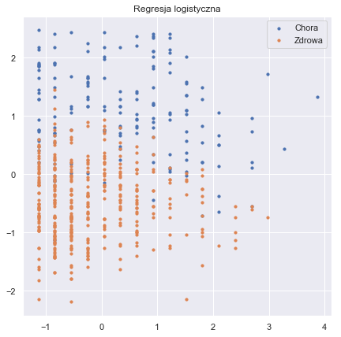

```python
wykres_klasyfikacja(y_pred_train_lr)
plt.title("Regresja logistyczna")
plt.show()
```

### K najbliższych sąsiadów

Wyniki klasyfikacji za pomocą metody K najbliższych sąsiadów.

Metoda ta oblicza odległość nowego punktu danych do wszystkich innych punktów danych treningowych. Odległość może być dowolnego typu, np. Euklidesa lub Manhattan itd. Następnie wybiera najbliższe punkty danych K, gdzie K może być dowolną liczbą całkowitą. Wreszcie przypisuje punkt danych do klasy, do której należy większość punktów danych K. Algorytm k-najbliższego sąsiada opiera się na prostej idei przewidywania nieznanych wartości poprzez dopasowanie ich do najbardziej podobnych znanych wartości.

Model został stworzony w oparciu o najlepsze wartości parametrów: leaf size - rozmiar liścia przekazany do BallTree lub KDTree, może wpłynąć na szybkość budowy i zapytania, a także pamięć wymaganą do przechowywania drzewa, n_neighbors - liczba sąsiadów oraz p - parametr mocy dla miary Minkowskiego. Parametry estymatora są optymalizowane za pomocą sprawdzianu krzyżowego w siatce parametrów.

```python
#looking for the best params for the model and prediction based on this params
leaf_size = list(range(1,50))
n_neighbors = list(range(1,30))
p=[1,2]

hyperparameters = dict(leaf_size = leaf_size,n_neighbors = n_neighbors,p=p)
knn = KNeighborsClassifier()

clf = GridSearchCV(knn,hyperparameters, cv=10)
knn_best = clf.fit(X_train,y_train)

best_leaf_size = knn_best.best_estimator_.get_params()['leaf_size']
best_neighbors = knn_best.best_estimator_.get_params()['n_neighbors']
best_p = knn_best.best_estimator_.get_params()['p']

y_pred_train_knn = knn_best.predict(X_train)
y_pred_test_knn = knn_best.predict(X_test)
KNN_cm_train = confusion_matrix(y_train, y_pred_train_knn)
KNN_cm_test = confusion_matrix(y_test, y_pred_test_knn)
```

**Trafność prognozy na zbiorze treningowym i testowym:**

```python
print("Trafność na zbiorze treningowym: ",round(accuracy_score(y_train,y_pred_train_knn),3))
print("Trafność na zbiorze testowym: ",round(accuracy_score(y_test,y_pred_test_knn),3))
```

```
Trafność na zbiorze treningowym:  0.803
Trafność na zbiorze testowym:  0.762
```

**Macierze dopasowań obu zbiorów:**

```python
print("\nMacierz dopasowań na zbiorze treningowym: \n\n" ,pd.DataFrame(KNN_cm_train))
print("\nMacierz dopasowań na zbiorze testowym: \n\n" ,pd.DataFrame(KNN_cm_test))
```

```
Macierz dopasowań na zbiorze treningowym:

      0    1
0  310   33
1   73  121

Macierz dopasowań na zbiorze testowym:

      0   1
0  141  16
1   39  35
```

Widać, że model lepiej poradził sobie na zbiorze treningowym. Ma więcej poprawnie zaklasyfikowanych 0 niż model Regresji logistycznej i tyle samo poprawnie zaklasyfikowanych 1. Natomiast jeśli chodzi o zbiór testowy, to lepiej przypisywał 0 i gorzej 1.

**Wykres pokazujący które obserwacje zostały przypisane do poszczególnych klas:**

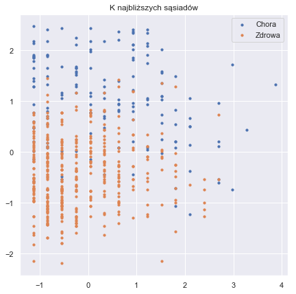

```python
wykres_klasyfikacja(y_pred_train_knn)
plt.title("K najbliższych sąsiadów")
plt.show()
```

### Drzewa decyzyjne

Wyniki klasyfikacji za pomocą Drzewa decyzyjnego.

Drzewo składają się z korzenia oraz gałęzi prowadzących z korzenia do kolejnych wierzchołków. Wierzchołki, z których wychodzi co najmniej jedna krawędź, są nazywane węzłami, a pozostałe wierzchołki – liśćmi. W każdym węźle sprawdzany jest pewien warunek dotyczący danej obserwacji, i na jego podstawie wybierana jest jedną z gałęzi prowadząca do kolejnego wierzchołka. Klasyfikacja danej obserwacji polega na przejściu od korzenia do liścia i przypisaniu do tej obserwacji klasy zapisanej w danym liściu.

Model został stworzony w oparciu o najlepsze wartości parametrów: criterion - unkcja pomiaru jakości podziału, max_depth - maksymalna głębokość drzewa. Parametry estymatora są optymalizowane za pomocą sprawdzianu krzyżowego w siatce parametrów.

```python
#looking for the best params for the model and prediction based on this params
criterion = ["gini", "entropy"]
max_depth = range(1,10)
hyperparameters = dict(criterion = criterion,max_depth = max_depth)
dt = DecisionTreeClassifier()

clf = GridSearchCV(dt,hyperparameters, cv=10)
dt_best = clf.fit(X_train,y_train)

best_criterion = dt_best.best_estimator_.get_params()['criterion']
best_max_depth = dt_best.best_estimator_.get_params()['max_depth']

y_pred_train_dt = dt_best.predict(X_train)
y_pred_test_dt = dt_best.predict(X_test)
DT_cm_train = confusion_matrix(y_train, y_pred_train_dt)
DT_cm_test = confusion_matrix(y_test, y_pred_test_dt)
```

**Trafność prognozy na zbiorze treningowym i testowym:**

```python
print("Trafność na zbiorze treningowym: ",round(accuracy_score(y_train,y_pred_train_dt),3))
print("Trafność na zbiorze testowym: ",round(accuracy_score(y_test,y_pred_test_dt),3))
```

```
Trafność na zbiorze treningowym:  0.838
Trafność na zbiorze testowym:  0.749
```

Klasyfikator drzewa decyzyjnego uzyskał 83,8% skuteczność na zbiorze treningowym i 74,9% na zbiorze testowym. Jest to najlepszy wynik na zbiorze treningowym biorąc pod uwagę poprzednie dwa klasyfikatory i najgorszy na zbiorze testowym. Różnice te są nieznaczne i nie sprawiają, że jest to najgorszy klasyfikator. Przy innym podziale zbioru mógłby osiągnąć najwyższy wynik na zbiorze testowym.

**Macierze dopasowań obu zbiorów:**

```python
print("\nMacierz dopasowań na zbiorze treningowym: \n\n" ,pd.DataFrame(DT_cm_train))
print("\nMacierz dopasowań na zbiorze testowym: \n\n" ,pd.DataFrame(DT_cm_test))
```

```
Macierz dopasowań na zbiorze treningowym:

      0    1
0  326   17
1   70  124

Macierz dopasowań na zbiorze testowym:

      0   1
0  140  17
1   41  33
```

Widać, że na zbiorze treningowym najlepiej zaklasyfikował poprawnie 0 i 1. Jeśli chodzi o zbiór testowy, poprawne zaklasyfikowanie 0 jest takie samo jak w Regresji logistycznej. Aczkolwiek najgorzej poradził sobie z poprawną klasyfikacją do klasy o mniejszej liczności - 1.

**Wykres pokazujący które obserwacje zostały przypisane do poszczególnych klas:**

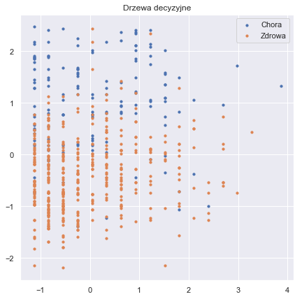

```python
wykres_klasyfikacja(y_pred_train_dt)
plt.title("Drzewa decyzyjne")
plt.show()
```

### Support Vector Machine

Wyniki klasyfikacji za pomocą metody Support Vector Machine.

Celem algorytmu SVM jest znalezienie hiperpłaszczyzny w przestrzeni N-wymiarowej (N - liczba cech), która wyraźnie klasyfikuje punkty danych. Aby oddzielić dwie klasy punktów danych, można wybrać wiele możliwych hiperpłaszczyzn. Celem jest znalezienie płaszczyzny, która ma maksymalny margines, czyli maksymalną odległość pomiędzy punktami danych obu klas. Maksymalizacja marginesu odległości zapewnia pewne wzmocnienie, dzięki czemu przyszłe punkty danych mogą być klasyfikowane z większą pewnością.

Model został stworzony w oparciu o najlepsze wartości parametrów: kernel - określa typ jądra, który ma być używany w algorytmie, C - oferuje najmniejszą różnicę między dokładnością treningową i testową. Parametry estymatora są optymalizowane za pomocą sprawdzianu krzyżowego w siatce parametrów.

```python
#looking for the best params for the model and prediction based on this params
kernels =['linear', 'poly', 'rbf', 'sigmoid']
c_values = [10, 1.0, 0.1, 0.01]
hyperparameters = dict(kernel = kernels,C = c_values)
svm = SVC()
clf = GridSearchCV(svm,hyperparameters, cv=10)
svm_best = clf.fit(X_train,y_train)

best_kernel = svm_best.best_estimator_.get_params()['kernel']
best_c_svm = svm_best.best_estimator_.get_params()['C']

y_pred_train_svm = svm_best.predict(X_train)
y_pred_test_svm = svm_best.predict(X_test)
SVM_cm_train = confusion_matrix(y_train, y_pred_train_svm)
SVM_cm_test = confusion_matrix(y_test, y_pred_test_svm)
```

**Trafność prognozy na zbiorze treningowym i testowym:**

```python
print("Trafność na zbiorze treningowym: ",round(accuracy_score(y_train,y_pred_train_svm),3))
print("Trafność na zbiorze testowym: ",round(accuracy_score(y_test,y_pred_test_svm),3))
```

```
Trafność na zbiorze treningowym:  0.836
Trafność na zbiorze testowym:  0.719
```

**Macierze dopasowań zbioru treningowego i testowego:**

```python
print("\nMacierz dopasowań na zbiorze treningowym: \n\n" ,pd.DataFrame(SVM_cm_train))
print("\nMacierz dopasowań na zbiorze testowym: \n\n" ,pd.DataFrame(SVM_cm_test))
```

```
Macierz dopasowań na zbiorze treningowym:

      0    1
0  315   28
1   60  134

Macierz dopasowań na zbiorze testowym:

      0   1
0  134  23
1   42  32
```

Na zbiorze treningowym metoda ta osiągnęła najlepszy wynik pod względem poprawnej klasyfikacji mniej licznego zbioru - 1. Zaklasyfikował poprawnie do tej grupy aż o 10 obserwacji więcej niż Drzewa decyzyjne. Natomiast w zbiorze testowym był to najgorszy wynik ze wszystkich użytych klasyfikatorów.

**Wykres pokazujący które obserwacje zostały przypisane do poszczególnych klas:**

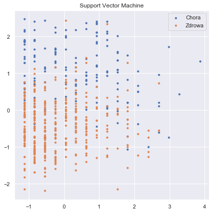

```python
wykres_klasyfikacja(y_pred_train_svm)
plt.title("Support Vector Machine")
plt.show()
```

### Porównanie trafności prognozy poszczególnych modeli z uwzględnieniem k-krotnej walidacji krzyżowej

Ze względu na to, że wynik poszczególnych metod może różnić się w zależności od tego, w jaki sposób zbiór zostanie podzielony na treningowy i testowy, wykonano jeszcze raz prognozy powyższych modeli z uwzględnieniem k-krotnej walidacji krzyżowej i najlepszych parametrów. K-krotna walidacja krzyżowa dokonuje losowego podziału zbioru danych na k podzbiorów, gdzie k-1 podzbiorów wykorzystywanych jest do trenowania modelu. Proces powtarzany jest k-krotnie, a w efekcie otrzymujemy k modeli i oszacowań skuteczności. Ostateczny wynik oszacowania uzyskiwany jest poprzez uśrednienie wyników uzyskanych ze wszystkich iteracji.

**Trafności prognozy dla poszczególnych modeli:**

```python
#comparison of accuracy measure for each model
models = []
models.append(("LR",LogisticRegression(solver = best_solver, C=best_c_lr)))
models.append(("KNN",KNeighborsClassifier(leaf_size=best_leaf_size,n_neighbors=best_neighbors, p=best_p)))
models.append(("DT",DecisionTreeClassifier(criterion=best_criterion,max_depth= best_max_depth)))
models.append(("SVM",SVC(kernel=best_kernel, C=best_c_svm)))

results = []
names = []
for name,model in models:
    kfold = KFold(n_splits=8, random_state=32)
    cv_result = cross_val_score(model,X_train,y_train, cv = kfold,scoring = "accuracy")
    names.append(name)
    results.append(cv_result)
for i in range(len(names)):
    print(names[i],round(results[i].mean(),3))
```

```
LR 0.769
KNN 0.767
DT 0.717
SVM 0.786
```

**Boxploty dla poszczególnych metod:**

```
[Text(0,0,'LR'), Text(0,0,'KNN'), Text(0,0,'DT'), Text(0,0,'SVM')]
```

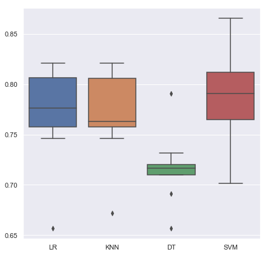

```python
#boxplots for each models
fig, ax = plt.subplots(ncols = 1, nrows=1, figsize=(7,7))
ax = sns.boxplot(data=results)
ax.set_xticklabels(names)
```

Największy zakres ma Support Vector Machine - od 70% do prawie 90% trafności. Przy dobraniu odpowiednich parametrów można spodziewać się bardzo dobrych rezultatów ze strony tej metody. Regresja logistyczna i K najbliższych sąsiadów dają posobne wyniki, jednak warto zwrócić uwagę na medianę - znajduje się wyżej w Regresji logistycznej. Drzewa wypadły zdecydowanie najgorzej. Ich maksymalna wartość nie przekracza 73%, oprócz 1 outliera.

# 5. Klasteryzacja

Klasteryzacja jest metodą klasyfikacji "bez nadzoru". Jest to metoda dokonująca grupowania elementów we względnie jednorodne klasy. Podstawą grupowania w większości algorytmów jest podobieństwo pomiędzy elementami – wyrażone przy pomocy funkcji (metryki) podobieństwa.

W projekcie zostaną użyte dwie metody grupowania:

- Grupowanie hierarchiczne - Metoda Warda
- Metoda k- średnich

## Metoda Warda

Metoda Warda zmierza ona do minimalizacji sumy kwadratów odchyleń dowolnych dwóch skupień, które mogą zostać uformowane na każdym etapie. Traktowana jest jako bardzo efektywna, chociaż zmierza do tworzenia skupień o małej wielkości. Daje pełną kontrolę nad wynikową liczbą grup oraz przedstawia najbardziej naturalne skupiska elementów.

Liczba klastrów w metodzie Warda zostanie wybrana na podstawie dendrogramu.

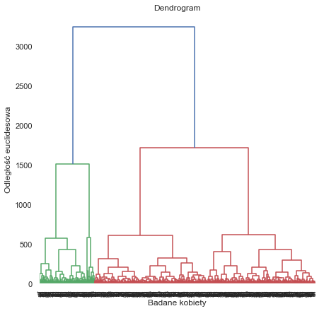

```python
#dendrogram for choosing the number of clusters
fig, ax = plt.subplots(ncols = 1, nrows=1, figsize=(7,7))
sch.dendrogram(sch.linkage(X, method = 'ward'))
plt.xlabel('Badane kobiety')
plt.ylabel('Odległość euclidesowa')
plt.title('Dendrogram')
plt.show()
```

Dendrogram wskazuje na podział badanych kobiet na dwie grupy. W takim wypadku zostanie przeprowadzone grupowanie z dwoma klastrami.

```python
#Ward method clustering
hc = AgglomerativeClustering(n_clusters = 2, affinity = 'euclidean', linkage = 'ward')
y_hc = hc.fit_predict(X)

#showing descriptive statistics for the first group
Ward_1 = pd.DataFrame(X[y_hc == 0, :]).describe()
Ward_1.columns = ['Pregnancies', 'Glucose', 'BloodPressure', 'SkinThickness', 'Insulin',
       'BMI', 'DiabetesPedigreeFunction', 'Age']
Ward_1
```

|  | Pregnancies | Glucose | BloodPressure | SkinThickness | Insulin | BMI | DiabetesPedigreeFunction | Age |
| --- | --- | --- | --- | --- | --- | --- | --- | --- |
| count | 614.000000 | 614.000000 | 614.000000 | 614.000000 | 614.000000 | 614.000000 | 614.000000 | 614.000000 |
| mean | 3.812704 | 117.332088 | 72.219310 | 28.543216 | 120.977022 | 32.221970 | 0.471057 | 32.781759 |
| std | 3.376210 | 28.099416 | 12.153197 | 10.233360 | 56.412187 | 6.839403 | 0.322940 | 11.241437 |
| min | 0.000000 | 44.000000 | 24.000000 | 7.743224 | 4.008390 | 18.200000 | 0.078000 | 21.000000 |
| 25% | 1.000000 | 98.000000 | 64.000000 | 21.000000 | 75.250000 | 27.325000 | 0.247250 | 24.000000 |
| 50% | 3.000000 | 113.000000 | 72.000000 | 28.000000 | 118.335239 | 32.000000 | 0.380000 | 29.000000 |
| 75% | 6.000000 | 132.750000 | 80.000000 | 35.000000 | 167.750000 | 36.175000 | 0.612750 | 40.000000 |
| max | 17.000000 | 199.000000 | 122.000000 | 99.000000 | 249.000000 | 67.100000 | 2.420000 | 81.000000 |

Grupa pierwsza ma liczność 614 obserwacji. To kobiety, które miały ok. 3-4 ciąże za sobą. Mają podwyższony poziom glukozy i insuliny, lecz pozostałe wyniki są w normie. Po BMI można sądzić, że cierpią na otyłość. Są to w większości kobiety zdrowe. Wracając do wykresu częstości zmiennej zależnej, sądzić można, że te 500 zdrowych kobiet mieści się własnie w tej grupie.

```python
#showing descriptive statistics for the second group
Ward_2 = pd.DataFrame(X[y_hc == 1, :]).describe()
Ward_2.columns = ['Pregnancies', 'Glucose', 'BloodPressure', 'SkinThickness', 'Insulin',
       'BMI', 'DiabetesPedigreeFunction', 'Age']
Ward_2
```

|  | Pregnancies | Glucose | BloodPressure | SkinThickness | Insulin | BMI | DiabetesPedigreeFunction | Age |
| --- | --- | --- | --- | --- | --- | --- | --- | --- |
| count | 154.000000 | 154.000000 | 154.000000 | 154.000000 | 154.000000 | 154.000000 | 154.000000 | 154.000000 |
| mean | 3.974026 | 139.285714 | 72.624372 | 30.953169 | 325.899102 | 33.476163 | 0.475143 | 35.071429 |
| std | 3.350833 | 33.292075 | 12.821698 | 10.071504 | 101.367805 | 7.069560 | 0.363966 | 13.520310 |
| min | 0.000000 | 57.000000 | 46.000000 | 5.599774 | 231.000000 | 18.200000 | 0.100000 | 21.000000 |
| 25% | 1.000000 | 112.000000 | 64.000000 | 24.000000 | 265.007444 | 28.100000 | 0.232250 | 24.000000 |
| 50% | 3.000000 | 141.500000 | 70.000000 | 31.000000 | 287.392079 | 33.700000 | 0.350000 | 30.000000 |
| 75% | 6.000000 | 165.000000 | 81.961535 | 39.000000 | 341.921600 | 38.175000 | 0.646500 | 42.000000 |
| max | 14.000000 | 198.000000 | 110.000000 | 54.000000 | 846.000000 | 52.300000 | 2.329000 | 67.000000 |

## Metoda k-średnich

Przy pomocy metody k-średnich zostanie utworzonych k różnych możliwie odmiennych skupień. Algorytm ten polega na przenoszeniu obiektów ze skupienia do skupienia tak długo aż zostaną zoptymalizowane zmienności wewnątrz skupień oraz pomiędzy skupieniami. Podobieństwo w skupieniu powinno być jak największe, zaś osobne skupienia powinny się maksymalnie od siebie różnić.

Liczba klastrów do metody k średnich zostanie wybrana na podstawie metody łokciowej.

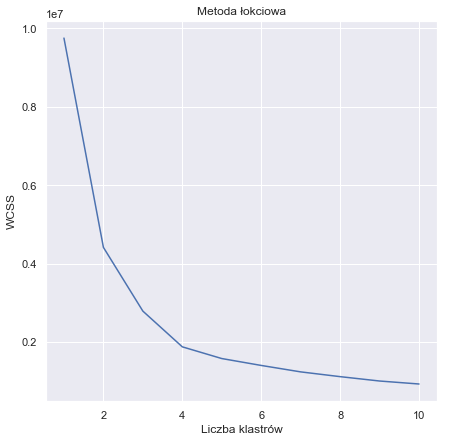

```python
#elbow method for choosing the number of clusters
fig, ax = plt.subplots(ncols = 1, nrows=1, figsize=(7,7))
wcss = []
for i in range(1, 11):
    kmeans = KMeans(n_clusters = i, init = 'k-means++', random_state = 42)
    kmeans.fit(X)
    wcss.append(kmeans.inertia_)
plt.plot(range(1, 11), wcss)
plt.xlabel('Liczba klastrów')
plt.ylabel('WCSS')
plt.title('Metoda łokciowa')
plt.show()
```

Powyżej 4 klastrów wartość WCSS spada nieznacznie. W takim wypadku do metody k średnich zostaną użyte 4 klastry.

```python
#k-means clustering on the whole dataset
kmeans = KMeans(n_clusters = 4, init = 'k-means++', random_state = 0)
y_kmeans = kmeans.fit_predict(X)
```

```python
#showing descriptive statistics for the first group
kmeans_1 = pd.DataFrame(X[y_kmeans == 0, :]).describe()
kmeans_1.columns = ['Pregnancies', 'Glucose', 'BloodPressure', 'SkinThickness', 'Insulin',
       'BMI', 'DiabetesPedigreeFunction', 'Age']
kmeans_1
```

|  | Pregnancies | Glucose | BloodPressure | SkinThickness | Insulin | BMI | DiabetesPedigreeFunction | Age |
| --- | --- | --- | --- | --- | --- | --- | --- | --- |
| count | 316.000000 | 316.000000 | 316.000000 | 316.000000 | 316.000000 | 316.000000 | 316.000000 | 316.000000 |
| mean | 3.458861 | 105.223710 | 70.656132 | 26.829553 | 74.687353 | 30.989065 | 0.461551 | 30.667722 |
| std | 3.195466 | 22.847289 | 11.909099 | 10.144916 | 28.615367 | 6.510628 | 0.322908 | 10.571617 |
| min | 0.000000 | 44.000000 | 24.000000 | 7.743224 | 4.008390 | 18.200000 | 0.084000 | 21.000000 |
| 25% | 1.000000 | 89.000000 | 64.000000 | 19.000000 | 54.601470 | 26.275000 | 0.243250 | 23.000000 |
| 50% | 2.000000 | 102.000000 | 70.000000 | 25.903912 | 76.000000 | 30.500000 | 0.365500 | 27.000000 |
| 75% | 5.000000 | 119.000000 | 78.000000 | 33.040862 | 97.478718 | 34.700000 | 0.600000 | 36.000000 |
| max | 15.000000 | 184.000000 | 106.000000 | 63.000000 | 130.908263 | 59.400000 | 2.420000 | 81.000000 |

Liczność grupy pierwszej wynosi 316 kobiet. Są to kobiety, które mają średnio 3-4 ciąże za sobą, poziom glukozy lekko powyżej normy, o prawidłowym ciśnieniu rozkurczowym krwi. Fałd skóry to ok 2,6 cm, poziom insuliny jest również lekko powyżej normy, a BMI wskazujące na otyłość. Są to kobiety średnio w wieku 30 lat. Można podejrzewać, że jest to grupa kobiet młodych (75% jest poniżej 36 roku życia), które są otyłe i są raczej zdrowe.

```python
#showing descriptive statistics for the second group
kmeans_2 = pd.DataFrame(X[y_kmeans == 1, :]).describe()
kmeans_2.columns = ['Pregnancies', 'Glucose', 'BloodPressure', 'SkinThickness', 'Insulin',
       'BMI', 'DiabetesPedigreeFunction', 'Age']
kmeans_2
```

|  | Pregnancies | Glucose | BloodPressure | SkinThickness | Insulin | BMI | DiabetesPedigreeFunction | Age |
| --- | --- | --- | --- | --- | --- | --- | --- | --- |
| count | 149.000000 | 149.000000 | 149.000000 | 149.000000 | 149.000000 | 149.000000 | 149.00000 | 149.000000 |
| mean | 4.140940 | 137.020134 | 73.560442 | 30.877347 | 284.204333 | 33.696840 | 0.45653 | 35.140940 |
| std | 3.466091 | 32.634228 | 13.264692 | 10.121859 | 43.319377 | 7.238706 | 0.30840 | 13.076707 |
| min | 0.000000 | 57.000000 | 46.000000 | 5.599774 | 225.000000 | 18.200000 | 0.08800 | 21.000000 |
| 25% | 1.000000 | 111.000000 | 64.000000 | 24.000000 | 248.897931 | 27.800000 | 0.23100 | 24.000000 |
| 50% | 4.000000 | 137.000000 | 72.000000 | 31.000000 | 276.376311 | 33.700000 | 0.34400 | 31.000000 |
| 75% | 6.000000 | 162.000000 | 82.000000 | 39.000000 | 310.000000 | 38.100000 | 0.65400 | 41.000000 |
| max | 14.000000 | 198.000000 | 110.000000 | 54.000000 | 402.000000 | 57.300000 | 1.60000 | 67.000000 |

Grupa druga liczy 149 obserwacji. To kobiety średnio młode ( 75% obserwacji poniżej 41 lat), które były średnio w 4 ciążach. Ich poziom glukozy jest podwyższony, mają ciśnienie rozkurczowe w normie, średnia grubość fałdu skóry to ok. 3 cm, a poziom insuliny jest kilkukrotnie podwyższony. Mają podwyższone BMI, co wskazuje, że są to kobiety z otyłością 2 stopnia. Można przypuszczać, że znajdują się w tej grupie zarówno kobiety zdrowe i chore.

```python
#showing descriptive statistics for the third group
kmeans_3 = pd.DataFrame(X[y_kmeans == 2, :]).describe()
kmeans_3.columns = ['Pregnancies', 'Glucose', 'BloodPressure', 'SkinThickness', 'Insulin',
       'BMI', 'DiabetesPedigreeFunction', 'Age']
kmeans_3
```

|  | Pregnancies | Glucose | BloodPressure | SkinThickness | Insulin | BMI | DiabetesPedigreeFunction | Age |
| --- | --- | --- | --- | --- | --- | --- | --- | --- |
| count | 281.000000 | 281.000000 | 281.000000 | 281.000000 | 281.000000 | 281.000000 | 281.000000 | 281.000000 |
| mean | 4.135231 | 129.516760 | 73.462934 | 30.067355 | 166.357620 | 33.198381 | 0.479972 | 35.039146 |
| std | 3.487150 | 27.293753 | 12.102767 | 9.994222 | 28.629245 | 6.775249 | 0.326613 | 11.729476 |
| min | 0.000000 | 61.000000 | 40.000000 | 8.000000 | 107.804182 | 19.100000 | 0.078000 | 21.000000 |
| 25% | 1.000000 | 109.000000 | 66.000000 | 24.000000 | 141.478600 | 28.000000 | 0.253000 | 25.000000 |
| 50% | 3.000000 | 126.000000 | 74.000000 | 29.717553 | 166.000000 | 33.200000 | 0.399000 | 32.000000 |
| 75% | 7.000000 | 146.000000 | 80.000000 | 36.000000 | 190.000000 | 37.600000 | 0.631000 | 42.000000 |
| max | 17.000000 | 199.000000 | 122.000000 | 99.000000 | 223.935471 | 67.100000 | 2.288000 | 69.000000 |

```python
#showing descriptive statistics for the fourth group
kmeans_4 = pd.DataFrame(X[y_kmeans == 3, :]).describe()
kmeans_4.columns = ['Pregnancies', 'Glucose', 'BloodPressure', 'SkinThickness', 'Insulin',
       'BMI', 'DiabetesPedigreeFunction', 'Age']
kmeans_4
```

|  | Pregnancies | Glucose | BloodPressure | SkinThickness | Insulin | BMI | DiabetesPedigreeFunction | Age |
| --- | --- | --- | --- | --- | --- | --- | --- | --- |
| count | 22.000000 | 22.000000 | 22.000000 | 22.000000 | 22.000000 | 22.000000 | 22.000000 | 22.000000 |
| mean | 3.681818 | 155.954545 | 72.540071 | 34.751482 | 535.191496 | 36.250000 | 0.620727 | 34.363636 |
| std | 3.271615 | 29.726495 | 10.935354 | 9.303815 | 103.379731 | 7.476296 | 0.570502 | 12.867624 |
| min | 0.000000 | 80.000000 | 52.000000 | 14.000000 | 415.000000 | 23.700000 | 0.128000 | 21.000000 |
| 25% | 1.000000 | 139.750000 | 64.427641 | 27.500000 | 478.500000 | 30.175000 | 0.271750 | 23.500000 |
| 50% | 2.500000 | 156.000000 | 70.000000 | 35.500000 | 495.000000 | 36.200000 | 0.510000 | 30.500000 |
| 75% | 6.750000 | 176.000000 | 82.000000 | 41.947463 | 544.500000 | 40.300000 | 0.670000 | 42.500000 |
| max | 11.000000 | 197.000000 | 90.000000 | 49.000000 | 846.000000 | 52.300000 | 2.329000 | 60.000000 |